# Urban Green Spaces: Exploratory Analysis (EDA)

mm5951

2022-12-02

The primary goal of this exploratory data analysis (EDA) is to provide a primary dataset of NYC Urban Green Spaces upon which regression analysis can be conducted with potentially associated dimensions (temperature, econometrics, and health outcomes).

Secondly, this EDA aims to provide:

- a descriptive analysis of the NYC Urban Green Spaces (UGS) primary dataset, as well as stratified analysis at the City Council District and Borough levels;
- relevant data visualizations of the above (notably including a map using the `leaflet` package);
- an attempt to fit the dataset into a linear regression model to understand elucidate differences in the amount and surface of UGS at the City Council District and Borough levels.

Potential **variable keys** (that is, to link among datasets) include borough, borough (“borough”), district (“zonedist1”), NYC building identifiers (“bin” & “bbl”) and coordenades (longitude and latitude).

## Data load & wrangling

The primary Urban Green Spaces (UGS) dataset is loaded (“UG_df_raw”). Next, `str()` and `skmir::skim()` functions are used to delve into the contents and structure of the resulting dataframe.

```r
UG_df_raw = read_csv("./data/GreenRoofData2016_20180917.csv", na = c("","Unknown"))

# Variables contained in the dataframe
str(UG_df_raw)
```

```
## spc_tbl_ [736 × 25] (S3: spec_tbl_df/tbl_df/tbl/data.frame)
##  $ fid            : num [1:736] 1 2 3 4 5 6 7 8 9 10 ...
##  $ bin            : num [1:736] 3393257 1010518 1010288 1001596 2117344 ...
##  $ bbl            : num [1:736] 3.01e+09 1.01e+09 1.01e+09 1.00e+09 2.02e+09 ...
##  $ gr_area        : num [1:736] 972 697 294 759 7204 ...
##  $ bldg_area      : num [1:736] 14058 4463 13218 4311 35892 ...
##  $ prop_gr        : num [1:736] 0.0691 0.1562 0.0222 0.1761 0.2007 ...
##  $ cnstrct_yr     : num [1:736] 1921 1920 1909 1920 2010 ...
##  $ doitt_id       : num [1:736] 485656 63711 84851 821215 1257143 ...
##  $ heightroof     : num [1:736] 59.2 13.7 93.8 100 206.2 ...
##  $ feat_code      : num [1:736] 2100 2100 2100 2100 2100 2100 2100 2100 2100 2100 ...
##  $ groundelev     : num [1:736] 90 21 7 21 10 62 13 30 12 62 ...
##  $ qa             : chr [1:736] "Good" "Good" "Good" "Good" ...
##  $ notes          : chr [1:736] NA NA NA NA ...
##  $ classified     : num [1:736] 1 1 1 1 1 1 1 1 1 1 ...
##  $ digitized      : num [1:736] 1 0 0 0 1 0 0 0 0 0 ...
##  $ newlyadded     : num [1:736] 0 0 0 0 0 0 0 0 0 0 ...
##  $ original_source: chr [1:736] "DPR" "classification" "classification" "classification" ...
##  $ address        : chr [1:736] "119 TROY AVENUE" "18 GREENWICH AVENUE" "479 GREENWICH STREET" "104 READE STREET" ...
##  $ borough        : chr [1:736] "BK" "MN" "MN" "MN" ...
##  $ ownertype      : chr [1:736] "C" NA NA NA ...
##  $ zonedist1      : chr [1:736] "PARK" "C1-6" "C6-2A" "C6-2A" ...
##  $ spdist1        : chr [1:736] NA NA NA "TMU" ...
##  $ bbl_fixed      : num [1:736] 0 0 0 0 0 0 0 0 1 0 ...
##  $ xcoord         : num [1:736] -73.9 -74 -74 -74 -73.9 ...
##  $ ycoord         : num [1:736] 40.7 40.7 40.7 40.7 40.8 ...
##  - attr(*, "spec")=
##   .. cols(
##   ..   fid = col_double(),
##   ..   bin = col_double(),
##   ..   bbl = col_double(),
##   ..   gr_area = col_double(),
##   ..   bldg_area = col_double(),
##   ..   prop_gr = col_double(),
##   ..   cnstrct_yr = col_double(),
##   ..   doitt_id = col_double(),
##   ..   heightroof = col_double(),
##   ..   feat_code = col_double(),
##   ..   groundelev = col_double(),
##   ..   qa = col_character(),
##   ..   notes = col_character(),
##   ..   classified = col_double(),
##   ..   digitized = col_double(),
##   ..   newlyadded = col_double(),
##   ..   original_source = col_character(),
##   ..   address = col_character(),
##   ..   borough = col_character(),
##   ..   ownertype = col_character(),
##   ..   zonedist1 = col_character(),
##   ..   spdist1 = col_character(),
##   ..   bbl_fixed = col_double(),
##   ..   xcoord = col_double(),
##   ..   ycoord = col_double()
##   .. )
##  - attr(*, "problems")=<externalptr>
```

```r
# Quick summary
skimr::skim(UG_df_raw)
```

Data summary

| Name | UG_df_raw |
| --- | --- |
| Number of rows | 736 |
| Number of columns | 25 |
| _______________________ |  |
| Column type frequency: |  |
| character | 8 |
| numeric | 17 |
| ________________________ |  |
| Group variables | None |

**Variable type: character**

| skim_variable | n_missing | complete_rate | min | max | empty | n_unique | whitespace |
| --- | --- | --- | --- | --- | --- | --- | --- |
| qa | 0 | 1.00 | 4 | 4 | 0 | 1 | 0 |
| notes | 687 | 0.07 | 24 | 81 | 0 | 12 | 0 |
| original_source | 0 | 1.00 | 3 | 32 | 0 | 9 | 0 |
| address | 1 | 1.00 | 10 | 25 | 0 | 703 | 0 |
| borough | 0 | 1.00 | 2 | 2 | 0 | 5 | 0 |
| ownertype | 384 | 0.48 | 1 | 1 | 0 | 5 | 0 |
| zonedist1 | 1 | 1.00 | 2 | 9 | 0 | 103 | 0 |
| spdist1 | 493 | 0.33 | 1 | 4 | 0 | 42 | 0 |

**Variable type: numeric**

| skim_variable | n_missing | complete_rate | mean | sd | p0 | p25 | p50 | p75 | p100 | hist |
| --- | --- | --- | --- | --- | --- | --- | --- | --- | --- | --- |
| fid | 0 | 1.00 | 368.50 | 2.126100e+02 | 1.00 | 184.75 | 368.50 | 552.25 | 736.00 | ▇▇▇▇▇ |
| bin | 1 | 1.00 | 1802099.99 | 1.103832e+06 | 1000053.00 | 1038288.00 | 1087698.00 | 3001684.00 | 5169276.00 | ▇▂▂▁▁ |
| bbl | 0 | 1.00 | 1719731131.37 | 1.032792e+09 | 1000087501.00 | 1006919383.50 | 1013893785.00 | 3001505001.00 | 5004870100.00 | ▇▂▂▁▁ |
| gr_area | 0 | 1.00 | 3600.76 | 1.264134e+04 | 10.10 | 442.96 | 1173.91 | 3139.93 | 277317.69 | ▇▁▁▁▁ |
| bldg_area | 1 | 1.00 | 23825.07 | 4.026255e+04 | 129.90 | 4327.22 | 12154.05 | 27709.05 | 692314.94 | ▇▁▁▁▁ |
| prop_gr | 1 | 1.00 | 0.20 | 4.900000e-01 | 0.00 | 0.06 | 0.12 | 0.23 | 12.56 | ▇▁▁▁▁ |
| cnstrct_yr | 17 | 0.98 | 1853.39 | 4.461600e+02 | 0.00 | 1915.00 | 1956.00 | 2006.00 | 2016.00 | ▁▁▁▁▇ |
| doitt_id | 1 | 1.00 | 734999.59 | 4.034906e+05 | 599.00 | 385610.50 | 750505.00 | 1109687.50 | 1281366.00 | ▃▅▃▃▇ |
| heightroof | 5 | 0.99 | 142.63 | 1.482000e+02 | 0.00 | 51.56 | 85.80 | 184.28 | 1408.38 | ▇▁▁▁▁ |
| feat_code | 1 | 1.00 | 2153.13 | 3.962100e+02 | 2100.00 | 2100.00 | 2100.00 | 2100.00 | 5110.00 | ▇▁▁▁▁ |
| groundelev | 2 | 1.00 | 41.37 | 3.317000e+01 | -4.00 | 15.00 | 32.00 | 61.00 | 168.00 | ▇▅▂▁▁ |
| classified | 0 | 1.00 | 0.93 | 2.500000e-01 | 0.00 | 1.00 | 1.00 | 1.00 | 1.00 | ▁▁▁▁▇ |
| digitized | 0 | 1.00 | 0.21 | 4.100000e-01 | 0.00 | 0.00 | 0.00 | 0.00 | 1.00 | ▇▁▁▁▂ |
| newlyadded | 0 | 1.00 | 0.01 | 1.100000e-01 | 0.00 | 0.00 | 0.00 | 0.00 | 1.00 | ▇▁▁▁▁ |
| bbl_fixed | 0 | 1.00 | 0.05 | 2.200000e-01 | 0.00 | 0.00 | 0.00 | 0.00 | 1.00 | ▇▁▁▁▁ |
| xcoord | 0 | 1.00 | -73.97 | 5.000000e-02 | -74.08 | -74.00 | -73.98 | -73.95 | -73.75 | ▁▇▂▁▁ |
| ycoord | 0 | 1.00 | 40.75 | 5.000000e-02 | 40.57 | 40.72 | 40.74 | 40.77 | 40.90 | ▁▂▇▃▁ |

```r
# Looking into key variables
UG_df_raw %>%
  count(borough)
```

```
## # A tibble: 5 × 2
##   borough     n
##   <chr>   <int>
## 1 BK        135
## 2 BX         82
## 3 MN        465
## 4 QN         50
## 5 SI          4
```

```r
UG_df_raw %>%
  count(ownertype)
```

```
## # A tibble: 6 × 2
##   ownertype     n
##   <chr>     <int>
## 1 C            60
## 2 M             2
## 3 O            13
## 4 P           223
## 5 X            54
## 6 <NA>        384
```

```r
UG_df_raw %>%
  count(zonedist1)
```

```
## # A tibble: 104 × 2
##    zonedist1     n
##    <chr>     <int>
##  1 BPC          19
##  2 C1-4          2
##  3 C1-6          6
##  4 C1-6A         7
##  5 C1-7          2
##  6 C1-7A         2
##  7 C1-8          1
##  8 C1-8X         4
##  9 C1-9          7
## 10 C1-9A         4
## # … with 94 more rows
```

Additionally, a secondary dataset with the same variables aggregated by City Council Districts is loaded. Although not the main object of this EDA, it might be useful to conduct homogeneity test at such level.

```r
UG_agg_df= read_csv("./data/NYC_CounDist_GreenRoof_Bldg_MaxHVI_PctCSO.csv", na = c("","Unknown")) %>%
  janitor::clean_names()
# Variables contained in the dataframe
str(UG_agg_df)
```

```
## spc_tbl_ [51 × 10] (S3: spec_tbl_df/tbl_df/tbl/data.frame)
##  $ coun_dist                     : num [1:51] 1 10 11 12 13 14 15 16 17 18 ...
##  $ borough                       : chr [1:51] "Manhattan" "Manhattan" "Bronx" "Bronx" ...
##  $ num_greenroofs                : num [1:51] 107 1 8 0 3 9 11 19 18 3 ...
##  $ greenroof_area_sqmeters       : num [1:51] 22113 203 5602 0 1006 ...
##  $ num_bldgs_total               : num [1:51] 5595 2605 10337 21453 30830 ...
##  $ bldg_area_total_sqmeters      : num [1:51] 2614865 1510679 2472521 2693529 3987455 ...
##  $ prop_greenroofs_of_bldgs      : num [1:51] 1.91e-02 3.84e-04 7.74e-04 0.00 9.73e-05 ...
##  $ prop_greenroofarea_of_bldgarea: num [1:51] 0.008457 0.000135 0.002266 0 0.000252 ...
##  $ hvi_nta_2018_max              : num [1:51] 4 3 4 5 5 5 5 5 5 4 ...
##  $ prop_gipriority               : num [1:51] 0.756 0.723 0.86 0.783 0.492 ...
##  - attr(*, "spec")=
##   .. cols(
##   ..   coun_dist = col_double(),
##   ..   Borough = col_character(),
##   ..   num_greenroofs = col_double(),
##   ..   greenroof_area_sqmeters = col_double(),
##   ..   num_bldgs_total = col_double(),
##   ..   bldg_area_total_sqmeters = col_double(),
##   ..   prop_greenroofs_of_bldgs = col_double(),
##   ..   prop_greenroofarea_of_bldgarea = col_double(),
##   ..   hvi_nta_2018_max = col_double(),
##   ..   prop_gipriority = col_double()
##   .. )
##  - attr(*, "problems")=<externalptr>
```

```r
# Quick summary
skimr::skim(UG_agg_df)
```

Data summary

| Name | UG_agg_df |
| --- | --- |
| Number of rows | 51 |
| Number of columns | 10 |
| _______________________ |  |
| Column type frequency: |  |
| character | 1 |
| numeric | 9 |
| ________________________ |  |
| Group variables | None |

**Variable type: character**

| skim_variable | n_missing | complete_rate | min | max | empty | n_unique | whitespace |
| --- | --- | --- | --- | --- | --- | --- | --- |
| borough | 0 | 1 | 5 | 16 | 0 | 6 | 0 |

**Variable type: numeric**

| skim_variable | n_missing | complete_rate | mean | sd | p0 | p25 | p50 | p75 | p100 | hist |
| --- | --- | --- | --- | --- | --- | --- | --- | --- | --- | --- |
| coun_dist | 0 | 1 | 26.00 | 14.87 | 1 | 13.50 | 26.00 | 38.50 | 51.00 | ▇▇▇▇▇ |
| num_greenroofs | 0 | 1 | 14.43 | 26.29 | 0 | 1.00 | 4.00 | 16.50 | 131.00 | ▇▁▁▁▁ |
| greenroof_area_sqmeters | 0 | 1 | 4827.62 | 9515.43 | 0 | 221.32 | 1122.80 | 5730.74 | 60525.15 | ▇▁▁▁▁ |
| num_bldgs_total | 0 | 1 | 21226.04 | 14964.35 | 2605 | 8525.00 | 17099.00 | 31168.00 | 52311.00 | ▇▇▃▂▃ |
| bldg_area_total_sqmeters | 0 | 1 | 3124465.92 | 1217296.04 | 1296261 | 2179110.44 | 3034687.20 | 3896195.79 | 6145895.86 | ▇▇▆▃▂ |
| prop_greenroofs_of_bldgs | 0 | 1 | 0.00 | 0.00 | 0 | 0.00 | 0.00 | 0.00 | 0.02 | ▇▁▁▁▁ |
| prop_greenroofarea_of_bldgarea | 0 | 1 | 0.00 | 0.00 | 0 | 0.00 | 0.00 | 0.00 | 0.02 | ▇▂▁▁▁ |
| hvi_nta_2018_max | 0 | 1 | 4.10 | 1.01 | 1 | 4.00 | 4.00 | 5.00 | 5.00 | ▁▁▃▆▇ |
| prop_gipriority | 0 | 1 | 0.69 | 0.32 | 0 | 0.50 | 0.78 | 0.95 | 1.00 | ▂▂▁▃▇ |

Next, the “UG_df_raw” is wrangled in order to generate a “UG_df” dataframe to be used for analysis & association to other workstreams of the project:

- select relevant variables using `select()`
- rename certain variables for comprehension using `remame()`
- re-order the variables using `arrange()`
- drop entries with now total green area available using `drop_na()`
- calculate percentage of green coverage of each building, as well as `recode()` borough names and ownership status, and convert sqm int sqm, using `mutate()`
- note ownertypes are aggregated into “Public”, “Private” and “Other” as per mapPLUTO definitions (refer to the codebook for more details). Given the presence of “na”, the `replace_na()` function is employed.

```r
UG_df = UG_df_raw %>%
  janitor::clean_names() %>%
  select(fid:notes, address:ycoord, -doitt_id, -qa, -feat_code, -spdist1, -bbl_fixed) %>%
  rename(
    UG_id = fid,
    latitude = ycoord,
    longitude = xcoord,
    cons_year = cnstrct_yr,
    green_area = gr_area,
    building_area = bldg_area
  ) %>%
  mutate(
    prop_gr = prop_gr*100,
    borough = recode(borough,
         BK = "Brooklyn",
         BX = "Bronx",
         MN = "Manhattan",
         QN = "Queens",
         SI = "Staten Island"),
    ownertype = recode(ownertype,
         C = "Public",
         M = "Other",
         O = "Public",
         P = "Private",
         X = "Other",
         P = "Private"),
    ownertype = replace_na(ownertype, "Private"),
    green_area = green_area*0.09290304,
    building_area = building_area*0.09290304,
    heightroof = heightroof*0.3048,
    groundelev = groundelev*0.3048
  ) %>%
  select(UG_id, cons_year, borough, zonedist1, address, ownertype, longitude, latitude, green_area:groundelev, everything()) %>%
  drop_na(green_area)
```

Checking that ownertype conversions have been done correctly:

```r
UG_df %>%
  count(ownertype)
```

```
## # A tibble: 3 × 2
##   ownertype     n
##   <chr>     <int>
## 1 Other        56
## 2 Private     607
## 3 Public       73
```

**NOTE** consider removing “bin” and “bbl” if they are not needed to match with tax-related data.

**VARIABLE DESCRIPTION** available within “README_1.html” file, found inside the data folder of this project. Consider merging all variable keys into 1 general README in the shared repo (“codebook”).

Dataset with aggregated UGS at the district level:

```r
UG_agg_df= read_csv("./data/NYC_CounDist_GreenRoof_Bldg_MaxHVI_PctCSO.csv", na = c("","Unknown")) %>%
  janitor::clean_names() %>%
  select(coun_dist:prop_greenroofarea_of_bldgarea) %>%
  rename(
    green_area = greenroof_area_sqmeters,
    building_area = bldg_area_total_sqmeters,
    prop_gbuild = prop_greenroofs_of_bldgs,
    prop_gr = prop_greenroofarea_of_bldgarea
  ) %>%
  mutate(
    prop_gr = prop_gr*100,
    prop_gbuild = prop_gbuild*100,
    green_area = green_area*0.09290304,
    building_area = building_area*0.09290304
  )
```

## Descriptive analysis

### Overall `UG_df` Datset Analysis

Overall, the “UG_df” contains contains 16 variables related to 736 urban green spaces in NYC. Details on the nature of its variables and summary values are found in the outputs above (chunk 1 of the data load & wrangling).

The total UGS area in NYC sums to 2.4620772^{5} square meter. The following table summarizes the average urban green space in NYC, including its size (in square meter), height (in meter) and percentage of green coverage (that is, the proportion of green space within the total building area). Key variables are summarized in the table below using `knitr:kable()`.

```r
UG_df %>%
  summarize(
    mean_green = mean(green_area, na.rm = TRUE),
    median_green = median(green_area),
    mean_height = mean(heightroof, na.rm = TRUE),
    perc_green = mean(prop_gr, na.rm = TRUE)
    ) %>%
    knitr::kable(digits = 2)
```

| mean_green | median_green | mean_height | perc_green |
| --- | --- | --- | --- |
| 334.52 | 109.06 | 43.47 | 19.63 |

### Stratified Analysis by Borough

When stratified by borough, differences in the amount of UGS as well as other the indicators used above become apparent. See the table below with a summary.

```r
UG_df %>%
  group_by(borough) %>%
  summarize(
    n = n(),
    tot_green = sum(green_area),
    mean_green = mean(green_area, na.rm = TRUE),
    median_green = median(green_area),
    min_green = min(green_area),
    max_green = max(green_area),
    mean_height = mean(heightroof, na.rm = TRUE),
    perc_green = mean(prop_gr, na.rm = TRUE)
    ) %>%
  arrange(desc(n)) %>%
  knitr::kable(digits = 2)
```

| borough | n | tot_green | mean_green | median_green | min_green | max_green | mean_height | perc_green |
| --- | --- | --- | --- | --- | --- | --- | --- | --- |
| Manhattan | 465 | 145265.38 | 312.40 | 90.50 | 0.94 | 25763.66 | 54.24 | 15.24 |
| Brooklyn | 135 | 50211.59 | 371.94 | 86.52 | 3.17 | 11906.34 | 21.95 | 21.53 |
| Bronx | 82 | 25476.31 | 310.69 | 174.85 | 21.43 | 2053.39 | 20.84 | 29.36 |
| Queens | 50 | 23427.54 | 468.55 | 214.85 | 7.36 | 2531.36 | 39.63 | 39.63 |
| Staten Island | 4 | 1826.90 | 456.72 | 449.31 | 94.75 | 833.52 | 19.45 | 17.98 |

### Stratified Analysis by City Council District

Although NYC city council districts typically correspond to borough sub-divisions, the equivalence is not perfect (note council district #8 belongs to boht Manhattan and Bronx, more info [here](https://council.nyc.gov/districts/)).

**Pending**: decide whether to perform descriptive analysis with the agg dataset, specially ratios by totals of buildings [or omit if there’s enough data].

## Data visualization

### Mapping UGS in NYC

Using the `leaflet` package to plot observations on a NY map. A `pal()` function is generated to establish a color according to the size of the UGS.

```r
pal <- colorNumeric(
  palette = "viridis",
  domain = UG_df$green_area)

UG_map = UG_df %>%
  mutate(
    green_area = round(green_area, digit = 2),
    heightroof = round(heightroof, digit = 2),
    click_label =
      str_c("<b>Area ", green_area, " sqm</b><br>Height ", heightroof, " m<br>")) %>%
  leaflet() %>%
  addProviderTiles(providers$CartoDB.Positron) %>%
  addCircleMarkers(~longitude, ~latitude, radius = .1, color = ~pal(green_area), popup = ~click_label)

UG_map
```

[interactive chart not shown]

**Interpretation**: concentration of UGS in Manhattan, and the southern the bigger.

### UGS development overtime in NYC

Next, the construction of UGS trends are investigated overtime. To do so, the `cumsum()` function is used over a generated dummy variable that allocates the value “1” to all UGS. Note that the observations with an invalid or missing construction year are ommited.

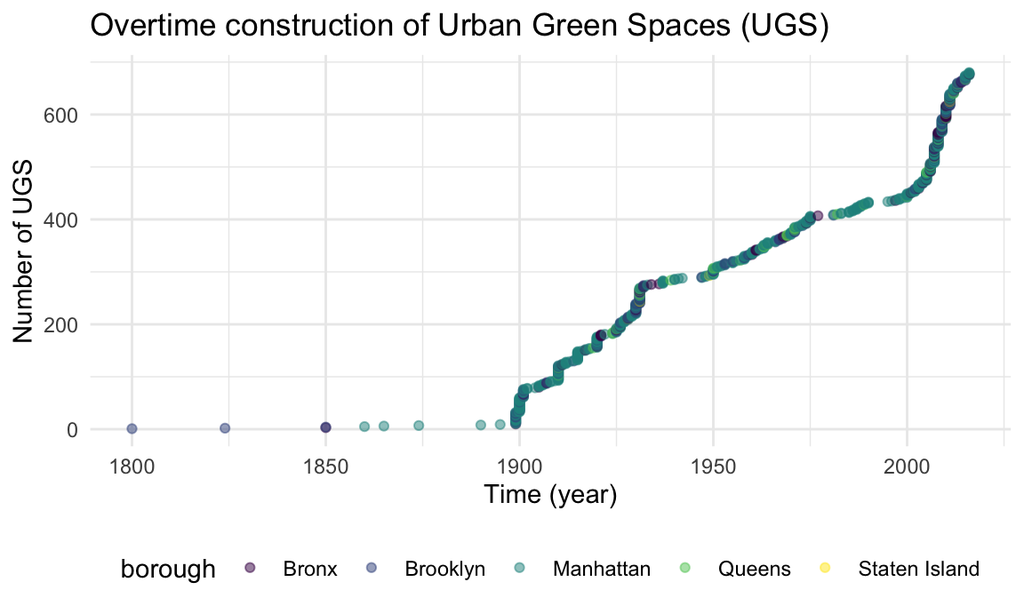

```r
UG_overtime = UG_df %>%
  drop_na(cons_year) %>%
  filter(cons_year !=0) %>%
  arrange(cons_year) %>%
  mutate(
    cumsum_dummy = 1,
    cumulative_UG = cumsum(cumsum_dummy)
  )

UG_overtime %>%
  group_by(borough) %>%
  ggplot(aes(cons_year, cumulative_UG, color = borough)) +
  geom_point(alpha = .5) +
  labs(
    title = "Overtime construction of Urban Green Spaces (UGS)",
    x = "Time (year)",
    y = "Number of UGS")
```

**Interpretation**: progressive construction of UGS overtime, rampant trend as of early 2000s (potentially linked to urban planning regulations and greater intest in climate change mitigation strategies).

**Consider**: split into 5 differnt lines per borough, as example [here](https://stackoverflow.com/questions/66105937/time-series-cumulative-data-plots-using-ggplot2)

### Distribution of UGS overall

Right-skewed distribution of UGS size.

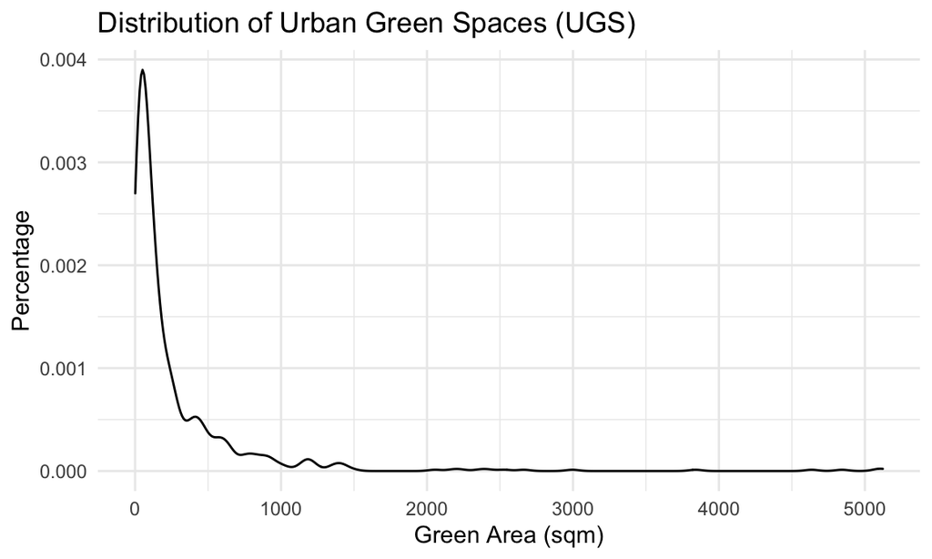

```r
UG_dist = UG_df %>%
  filter(green_area <6000) %>%
  ggplot(aes(x = green_area)) +
  geom_density() +
  labs(
    title = "Distribution of Urban Green Spaces (UGS)",
    x = "Green Area (sqm)",
    y = "Percentage")

UG_dist
```

### Distribution of UGS surface by borough

**Pending** : decide which to keep.

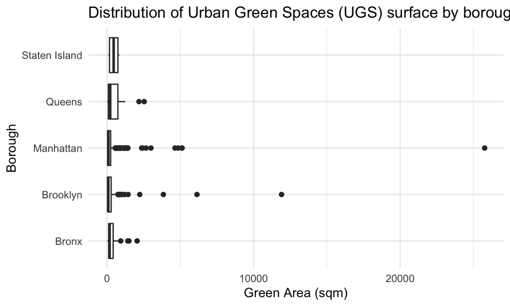

```r
UG_boxplot = UG_df %>%
  ggplot(aes(x = green_area, y = borough)) +
  geom_boxplot() +
  labs(
    title = "Distribution of Urban Green Spaces (UGS) surface by borough [boxplot]",
    x = "Green Area (sqm)",
    y = "Borough")

UG_boxplot
```

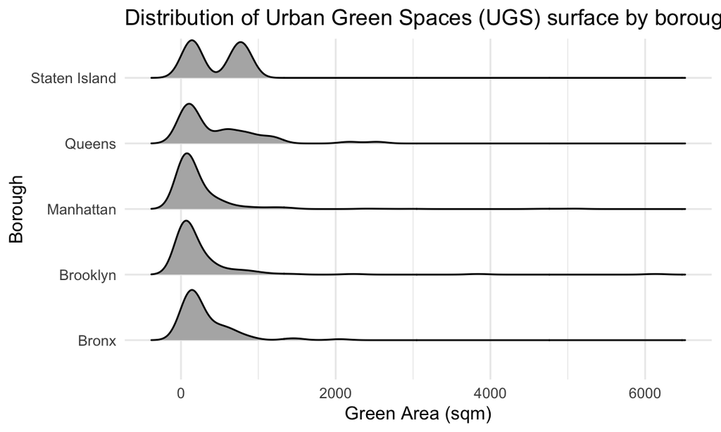

```r
UG_ridge = UG_df %>%
  filter(green_area <10000) %>%
  ggplot(aes(x = green_area, y = borough)) +
  geom_density_ridges(scale = .85) +
  labs(
    title = "Distribution of Urban Green Spaces (UGS) surface by borough [ggrides]",
    x = "Green Area (sqm)",
    y = "Borough")

UG_ridge
```

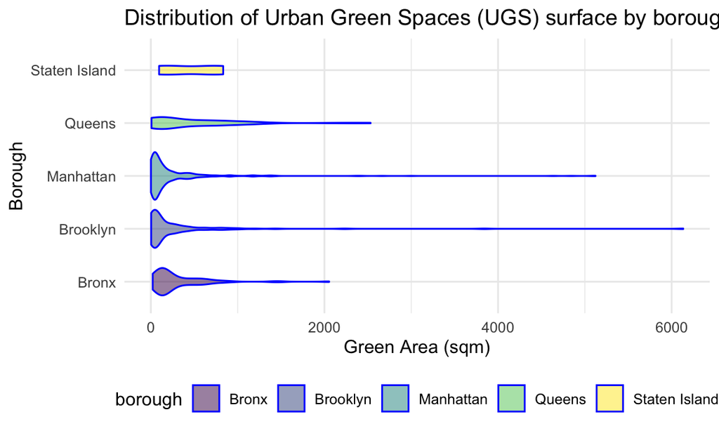

```r
UG_violin = UG_df %>%
  filter(green_area <10000) %>%
  ggplot(aes(x = green_area, y = borough)) +
  geom_violin(aes(fill = borough), color = "blue", alpha = .5) +
  theme(legend.position = "bottom") +
  labs(
    title = "Distribution of Urban Green Spaces (UGS) surface by borough [geom_violin]",
    x = "Green Area (sqm)",
    y = "Borough")

UG_violin
```

### Other

**Consider whether to include** no apparent association between UGS area and building height.

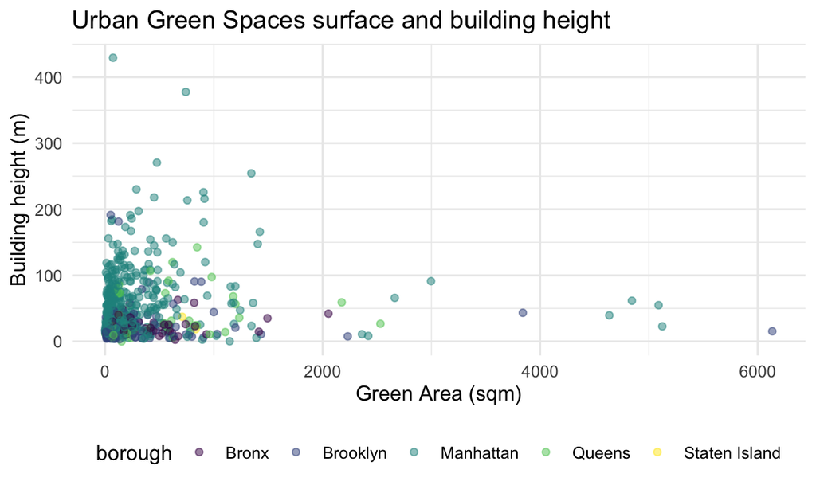

```r
UG_df %>%
  filter(green_area <10000) %>%
  ggplot(aes(x = green_area, y = heightroof)) +
  geom_point(aes(color = borough), alpha = .5) +
  labs(
    title = "Urban Green Spaces surface and building height",
    x = "Green Area (sqm)",
    y = "Building height (m)")
```

## **TBD** Test of homogeneity

To assess the distribution of Urban Green Spaces (UGS) at the City Council District and Borough levels. https://stats.oarc.ucla.edu/other/mult-pkg/whatstat/

```r
fit = lm(green_area ~ borough, data = UG_df)

summary(fit)
```

```
##
## Call:
## lm(formula = green_area ~ borough, data = UG_df)
##
## Residuals:
##     Min      1Q  Median      3Q     Max
##  -461.2  -284.4  -218.1   -34.6 25451.3
##
## Coefficients:
##                      Estimate Std. Error t value Pr(>|t|)
## (Intercept)           310.687    129.956   2.391   0.0171 *
## boroughBrooklyn        61.251    164.763   0.372   0.7102
## boroughManhattan        1.712    140.949   0.012   0.9903
## boroughQueens         157.864    211.154   0.748   0.4549
## boroughStaten Island  146.037    602.581   0.242   0.8086
## ---
## Signif. codes:  0 '***' 0.001 '**' 0.01 '*' 0.05 '.' 0.1 ' ' 1
##
## Residual standard error: 1177 on 731 degrees of freedom
## Multiple R-squared:  0.001402,   Adjusted R-squared:  -0.004062
## F-statistic: 0.2565 on 4 and 731 DF,  p-value: 0.9057
```

```r
fit %>%
  broom::tidy()
```

```
## # A tibble: 5 × 5
##   term                 estimate std.error statistic p.value
##   <chr>                   <dbl>     <dbl>     <dbl>   <dbl>
## 1 (Intercept)            311.        130.    2.39    0.0171
## 2 boroughBrooklyn         61.3       165.    0.372   0.710
## 3 boroughManhattan         1.71      141.    0.0121  0.990
## 4 boroughQueens          158.        211.    0.748   0.455
## 5 boroughStaten Island   146.        603.    0.242   0.809
```

```r
fit2 = lm(num_greenroofs ~ borough, data = UG_agg_df)
summary(fit2)
```

```
##
## Call:
## lm(formula = num_greenroofs ~ borough, data = UG_agg_df)
##
## Residuals:
##     Min      1Q  Median      3Q     Max
## -49.111  -5.941  -2.769   1.645  80.889
##
## Coefficients:
##                         Estimate Std. Error t value Pr(>|t|)
## (Intercept)               8.8750     7.4542   1.191 0.240055
## boroughBrooklyn          -0.9338     9.0396  -0.103 0.918181
## boroughManhattan         41.2361    10.2449   4.025 0.000216 ***
## boroughManhattan/ Bronx  17.1250    22.3627   0.766 0.447804
## boroughQueens            -5.1058     9.4742  -0.539 0.592602
## boroughStaten Island     -7.5417    14.2738  -0.528 0.599847
## ---
## Signif. codes:  0 '***' 0.001 '**' 0.01 '*' 0.05 '.' 0.1 ' ' 1
##
## Residual standard error: 21.08 on 45 degrees of freedom
## Multiple R-squared:  0.421,  Adjusted R-squared:  0.3567
## F-statistic: 6.545 on 5 and 45 DF,  p-value: 0.0001184
```

```r
fit2 %>%
  broom::tidy()
```

```
## # A tibble: 6 × 5
##   term                    estimate std.error statistic  p.value
##   <chr>                      <dbl>     <dbl>     <dbl>    <dbl>
## 1 (Intercept)                8.87       7.45     1.19  0.240
## 2 boroughBrooklyn           -0.934      9.04    -0.103 0.918
## 3 boroughManhattan          41.2       10.2      4.03  0.000216
## 4 boroughManhattan/ Bronx   17.1       22.4      0.766 0.448
## 5 boroughQueens             -5.11       9.47    -0.539 0.593
## 6 boroughStaten Island      -7.54      14.3     -0.528 0.600
```

Test of variance homogeneity (variances on the green_area by borough are significant)

```r
res <- bartlett.test(green_area ~ borough, data = UG_df)
res
```

```
##
##  Bartlett test of homogeneity of variances
##
## data:  green_area by borough
## Bartlett's K-squared = 172.94, df = 4, p-value < 2.2e-16
```

```r
res %>%
  broom::tidy()
```

```
## # A tibble: 1 × 4
##   statistic  p.value parameter method
##       <dbl>    <dbl>     <dbl> <chr>
## 1      173. 2.45e-36         4 Bartlett test of homogeneity of variances
```

ANOVA test of differences of green_area means by borough

```r
ANOVA1 = aov(green_area ~ borough, data = UG_df)

ANOVA1 %>%
  broom::tidy()
```

```
## # A tibble: 2 × 6
##   term         df       sumsq   meansq statistic p.value
##   <chr>     <dbl>       <dbl>    <dbl>     <dbl>   <dbl>
## 1 borough       4    1421088.  355272.     0.257   0.906
## 2 Residuals   731 1012334244. 1384862.    NA      NA
```

**ANOVA test of differences of the amount of UGS means by borough**

```r
ANOVA2 = aov(num_greenroofs ~ borough, data = UG_agg_df)

ANOVA2 %>%
  broom::tidy()
```

```
## # A tibble: 2 × 6
##   term         df  sumsq meansq statistic   p.value
##   <chr>     <dbl>  <dbl>  <dbl>     <dbl>     <dbl>
## 1 borough       5 14547.  2909.      6.54  0.000118
## 2 Residuals    45 20004.   445.     NA    NA
```

ALT [same idea as above but using the UG_overtime dataset – UG_df derivate]: ANOVA test of differences of the amount of UGS means by borough

```r
ANOVA2a = aov(cumsum_dummy ~ borough, data = UG_overtime)

ANOVA2a %>%
  broom::tidy()
```

```
## # A tibble: 2 × 6
##   term         df    sumsq   meansq statistic p.value
##   <chr>     <dbl>    <dbl>    <dbl>     <dbl>   <dbl>
## 1 borough       4 3.16e-28 7.89e-29      1.13   0.340
## 2 Residuals   675 4.70e-26 6.97e-29     NA     NA
```

## Acknowledgement

*The primary dataset was developed by The Nature Conservancy’s New York City Program (Mike Treglia and Emily Maxwell) with contributions (data aggregation and additional support) from Timon McPhearson of The Urban Systems Lab at The New School, Eric Sanderson of The Wildlife Conservation Society, and Greg Yetman of CIESIN at Columbia University.*

Treglia, Michael L., McPhearson, Timon, Sanderson, Eric W., Yetman, Greg, & Maxwell, Emily Nobel. (2018). Green Roofs Footprints for New York City, Assembled from Available Data and Remote Sensing (Version 1.0.0) [Available here](https://github.com/tnc-ny-science/NYC_GreenRoofMapping/tree/master/greenroof_gisdata/CurrentDatasets). Zenodo. http://doi.org/10.5281/zenodo.1469674